# ISA 365 Exam 1 Output Packet

Last complied on March 06, 2023

### Booking.com Test

This past October Booking’s homepage performed an experiment where instead of showing 5 location tiles, they tested a version that only showed 3 tiles at a time with an ability to slide for more - a carousel. They measured the total sales by day.

[figure not shown]

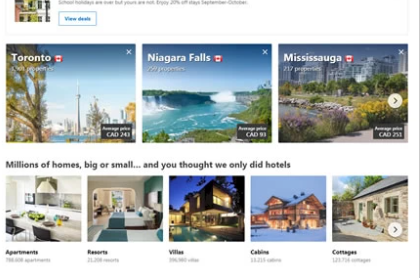

#### Summary

```r
head(df)
```

```
##   visit_id    sales variant
## 1    64134 235.4327       A
## 2    38597 151.9728       A
## 3    22152 357.5163       A
## 4      715 198.7320       A
## 5     5696 294.2526       A
## 6    99727 221.5526       A
```

```
## # A tibble: 2 × 4
##   variant    mean      sd count
##   <chr>     <dbl>   <dbl> <int>
## 1 A       178.200 95.8486    50
## 2 B       132.518 89.4821    50
```

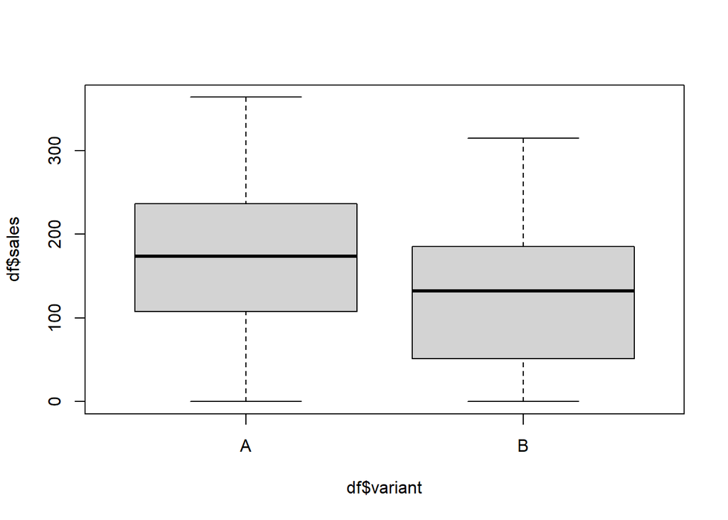

```r
boxplot(df$sales~df$variant)
```

#### Analysis

```r
t.test(df$sales~df$variant)
```

```
##
##  Welch Two Sample t-test
##
## data:  df$sales by df$variant
## t = 2.4634, df = 97.541, p-value = 0.01551
## alternative hypothesis: true difference in means between group A and group B is not equal to 0
## 95 percent confidence interval:
##   8.879589 82.483887
## sample estimates:
## mean in group A mean in group B
##        178.1999        132.5182
```

For variant A:

```r
178.200+qnorm(0.975)+91.0438 /sqrt(50)
```

```
## [1] 193.0355
```

```r
178.200-qnorm(0.975)+91.0438 /sqrt(50)
```

```
## [1] 189.1156
```

For variant A:

```r
178.200+qt(0.975, 49)+91.0438/sqrt(50)
```

```
## [1] 193.0851
```

```r
178.200-qt(0.975, 49)+91.0438/sqrt(50)
```

```
## [1] 189.066
```

For variant A:

```r
178.200+qnorm(0.95)+91.0438 /sqrt(50)
```

```
## [1] 192.7204
```

```r
178.200-qnorm(0.95)+91.0438 /sqrt(50)
```

```
## [1] 189.4307
```

For variant A:

```r
178.200+qt(0.95, 49)+91.0438/sqrt(50)
```

```
## [1] 192.7521
```

```r
178.200-qt(0.95, 49)+91.0438/sqrt(50)
```

```
## [1] 189.399
```

### Amazon Tests

Amazon ran an A/B test where they changed the classic list layout to a grid layout on certain product listing page. They measured the difference in purchase rates between the two layouts.

#### Preliminaries

First the Analysts at Amazon completed a preliminary sample size study. They were interested in finding a difference in purchase rates of 5%. Their current purchase rate is 3.45%

```r
power.t.test(n=NULL, sig.level = 0.05, power=0.8, delta = 0.05)
```

```
##
##      Two-sample t test power calculation
##
##               n = 6280.064
##           delta = 0.05
##              sd = 1
##       sig.level = 0.05
##           power = 0.8
##     alternative = two.sided
##
## NOTE: n is number in *each* group
```

```r
power.prop.test(n=NULL, sig.level = 0.05, power=0.8, p1=0.0345, p2=0.036225)
```

```
##
##      Two-sample comparison of proportions power calculation
##
##               n = 179954.9
##              p1 = 0.0345
##              p2 = 0.036225
##       sig.level = 0.05
##           power = 0.8
##     alternative = two.sided
##
## NOTE: n is number in *each* group
```

[figure not shown]

[figure not shown]

#### Summary

```r
head(df)
```

```
##   variant purchase
## 1       a        0
## 2       a        0
## 3       a        0
## 4       a        0
## 5       a        1
## 6       a        0
```

```r
df %>% group_by(variant) %>% summarise("mean"=mean(purchase), "sd"=sd(purchase), "count"=n())
```

```
## # A tibble: 2 × 4
##   variant      mean       sd count
##   <chr>       <dbl>    <dbl> <int>
## 1 a       0.0380933 0.191441  5014
## 2 b       0.0321867 0.176513  4971
```

```r
df %>% group_by(variant, purchase) %>%  summarise(n = n()) %>%
  mutate(freq = n / sum(n))
```

```
## # A tibble: 4 × 4
## # Groups:   variant [2]
##   variant purchase     n      freq
##   <chr>      <int> <int>     <dbl>
## 1 a              0  4823 0.961907
## 2 a              1   191 0.0380933
## 3 b              0  4811 0.967813
## 4 b              1   160 0.0321867
```

#### Analysis

```r
t.test(df$purchase~df$variant)
```

```
##
##  Welch Two Sample t-test
##
## data:  df$purchase by df$variant
## t = 1.603, df = 9930.9, p-value = 0.109
## alternative hypothesis: true difference in means between group a and group b is not equal to 0
## 95 percent confidence interval:
##  -0.00131615  0.01312946
## sample estimates:
## mean in group a mean in group b
##      0.03809334      0.03218668
```

```r
prop.test(x=c(191, 160), n=c(4823+191,4811+160))
```

```
##
##  2-sample test for equality of proportions with continuity correction
##
## data:  c(191, 160) out of c(4823 + 191, 4811 + 160)
## X-squared = 2.3965, df = 1, p-value = 0.1216
## alternative hypothesis: two.sided
## 95 percent confidence interval:
##  -0.001514851  0.013328163
## sample estimates:
##     prop 1     prop 2
## 0.03809334 0.03218668
```

### Etsy Test

Etsy has been a/b testing a simple and common social proof element on some of their product pages. They showed how many users have recently added an item in their shopping carts. They measured the purchase rates between each version.

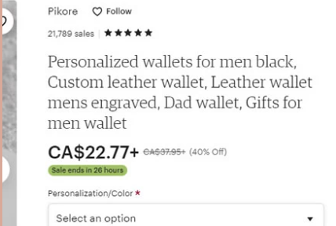

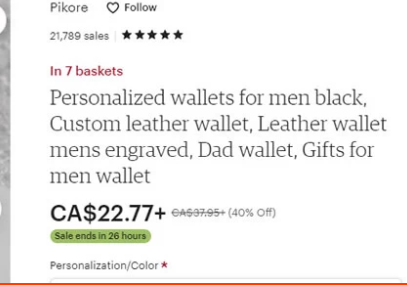

#### Summary

```r
head(df)
```

```
##   variant purchase
## 1       a        0
## 2       a        0
## 3       a        0
## 4       a        0
## 5       a        1
## 6       a        0
```

[output not shown]

#### Analysis

```r
iter=100000
a= 19+1
b=1237+1
a1=11+1
b1=1375 +1
count<-c()
for (i in 1:iter){
A<-rbeta(1, a, b)
B<-rbeta(1, a1, b1)
count[i]<-ifelse(A>B, 1, 0)


}
pdiff<-sum(count)/iter
pdiff
```

```
## [1] 0.95756
```

Individual intervals for variant A.

```r
a=19+1
b=1237+1
qbeta(0.975, a, b)
```

```
## [1] 0.02350423
```

```r
qbeta(0.025, a, b)
```

```
## [1] 0.009745172
```

```r
prop.test(x=19, n=1237+19)
```

```
##
##  1-sample proportions test with continuity correction
##
## data:  19 out of 1237 + 19, null probability 0.5
## X-squared = 1179.2, df = 1, p-value < 2.2e-16
## alternative hypothesis: true p is not equal to 0.5
## 95 percent confidence interval:
##  0.009394285 0.023987483
## sample estimates:
##          p
## 0.01512739
```

### Parachute Effectiveness Study

#### Random Sample from Population

```r
library(readxl)
df<-read_excel("I:/Classes/ISA 365/Datasets/class list.xlsx")
```

| Name |
| --- |
| Borton, Tylor |
| Clark, Kory |
| Darkwa, Kwabena |
| Feist, Danny |
| Graffin, Bryce |
| Jones, Morghan |

```r
set.seed(1234)
index<-sample(1:nrow(df),size=20)
index
```

```
##  [1] 28 22  9  5 38 16  4 34 39 67 26  6 15 14 52 55 62 54 21 40
```

#### Random Assignment

```r
study<-df[index,1]
treatment<-c(rep("parachute",10), rep("no parachute",10))
experiment<-data.frame(study, treatment)
```

| Name | treatment |
| --- | --- |
| Beardall, Matthew | parachute |
| Richer, Nick | parachute |
| McWilliams, Allison | parachute |
| Graffin, Bryce | parachute |
| Leithauser, Cate | parachute |
| Beickman, Lucia | parachute |
| Feist, Danny | parachute |
| Dosedel, Sean | parachute |
| Limauro, David | parachute |
| Xie, Yixuan | parachute |
| Truong, Brandon | no parachute |
| Jones, Morghan | no parachute |
| Barnes, Jack | no parachute |
| Winkhart, Cole | no parachute |
| Hoog, Ellie | no parachute |
| Kopitke, Amber | no parachute |
| Rodgers, Dunovan | no parachute |
| Khan, Salina | no parachute |
| Prokup, Nick | no parachute |
| Listermann, Zachary | no parachute |